# 1 Introduction

This chapter serves as an introduction to the programming API reference for the NDK software.

## 1.1 What This Document Covers

This Reference for the NDK is mainly a programming API reference guide. It is intended to aid in the development of network applications and describes the various API functions provided by the stack libraries.

Although this guide is the central reference document used when programming the stack, you should first see the *TI Network Developer’s Kit (NDK) User’s Guide* (SPRU523) to familiarize yourself with the stack libraries and with using the stack.

## 1.2 Introduction

The Network Developer’s Kit (NDK) is a platform for development and demonstration of network enabled applications on TI embedded processors. The code included in this NDK release is generic C code, which runs on a variety of TI devices.

Within the SimpleLink SDK, the Network Services SlNetSock module configures the NDK as the network stack for wired Ethernet communications.

The NDK stack serves as a rapid prototyping platform for the development of network and packet processing applications. It can be used to add network connectivity to existing applications for communications, configuration, and control. Using the components provided in the NDK, developers can quickly move from development concepts to working implementations attached to the network.

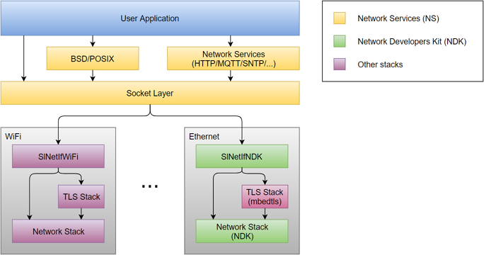

As Figure 1-1 shows, a user application can make calls using the standard BSD sockets APIs, or it can directly call into the SlNetSock layer to communicate with a network connection. The SlNetSock layer is a stack-independent layer between the user application and the service-specific stacks.

Within the SimpleLink SDK, the Network Services `SlNetSock` module configures the NDK as the network stack for wired Ethernet communications. `SlNetIfNDK` is the implementation of the SlNetSock interface for the NDK.

The NDK stack’s settings may be configured at run time by making calls to the NDK’s *Cfg()* functions.

The NDK is designed to provide a platform-independent, device-independent, and RTOS-independent API interface for use by the application. Many of the API modules described in this document and in the *TI Network Developer’s Kit (NDK) API Reference Guide* (SPRU524) are rarely used by applications. Instead they are available to those who are writing device drivers and network stacks.

A user application typically uses the following APIs provided by the NDK:

- **Cfg functions** add settings to the configuration database that determine which network services will be available to the application. See Section 4.2.
- **NC_ functions** cause the network services system to be initialized, started, and stopped. See Section 4.4.
- **TaskCreate() or native OS functions** to handle application threading. The NDK’s TaskCreate() API can be used to create a thread for any RTOS supported for the target device by the SimpleLink SDK. For most targets, this includes TI-RTOS Kernel and FreeRTOS. Alternatively, the native thread creation APIs can be used for the supported RTOS being used. For details, see the *TI Network Developer’s Kit (NDK) User’s Guide* (SPRU523).
- **NDK socket APIs** to perform socket actions such as accept, send, and receive. For a pure NDK application, these are the BSD-like NDK_*() functions described in Section 3.3. For SimpleLink SDK applications, you can use the standard BSD APIs provided via SlNetSock, which are described in Appendix F.

## 1.3 Supplemental API Information

The following information appears as appendices to this document. These sections contain optional information that may be useful in understanding the low-level application interface, but is not required when developing traditional network applications.

- **Appendix A Internal Stack Functions** The stack library internal function specification describes a subset of the low-level programming interface to the stack. These functions allow the application writer to make use of kernel level function APIs. As a general rule, it is not necessary to use this API for application development, although some of the sample applications included in the NDK make use of these function calls.
- **Appendix B Network Address Translation (NAT)** The stack library includes Network Address Translation module. This appendix describes the operational theory of NAT, and how to use the NAT functions included in the library.
- **Appendix C Point-to-Point Protocol (PPP)** The stack library has internal device sections for both traditional Ethernet, and PPP. The PPP module can act as PPP client, server, or both (assuming multiple interfaces). This appendix describes the operation of the PPP module, the PPP over Ethernet (PPPoE) module, and how to interface an HDLC based serial device.
- **Appendix D Hardware Adaptation Layer (HAL)** This appendix describes the hardware and operating system interfaces used by the stack. The information allows application programmers to call device drivers directly when needed. This appendix does not supply information about porting the HAL to a new platform.
- **Appendix E Web Programming with the HTTP Server** This appendix describes how to make use of the HTTP server included in the NDK. The main topics covered are adding Web content and writing CGI functions. There is also a description of the HTTP API used by CGI functions, and some CGI example applications.
- **Appendix F BSD Sockets Support** This appendix provides pointers to the Berkeley Software Distribution (BSD) API socket support layer, which is now provided by SlNetSock, which is part of the SimpleLink SDK.
- **Appendix G IPv6 Stack API** This appendix contains the data structure and API definitions exported by the IPv6 stack in the NDK. All IPv6 socket level APIs are also documented so that the application can use them for communication over IPv6 networks.

# 2 Operating System Abstraction API

The NDK OS Abstraction Layer (OSAL) uses a combination of native OS and POSIX APIs as a means of OS abstraction. In general, application writers should not use the OSAL APIs, with a few exceptions. One is the *TaskCreate()* function, which may be used as a convenience function for creating an NDK user thread that will make socket calls. Another is *TaskSelf()*, which can be used as an argument to *fdOpenSession()*.

To keep the stack system portable, it was coded to a very compact operating system abstraction. The stack can execute in any operating environment by porting the functions described here. Most of these functions will map directly to their native OS counterpart.

If you program to this API, your applications will execute on any system to which this abstraction is ported, but more importantly, because all the NDK functions are written to this layer, the behavior of the NDK can be altered by altering the implementation of this layer. This allows the stack to be tuned in how it interfaces to the native operating system.

## 2.1 Operating System Configuration

If you are using the Configuration Manager API to configure your application, the configuration options that regulate OS behavior are stored in a data structure. The types of properties defined in the structure are those that would typically be macros, but using a data structure allows the values to be changed without rebuilding the libraries. The structure is described here for completeness, but applications should use the configuration system to make alterations to these values.

If you are using XGCONF to configure your application, you can configure several aspects of the OS behavior in the **Scheduling** tab of the Global NDK module property page. When you build the *.cfg configuration file, the data structure described in the following section is generated internally and linked into your application. See the *TI Network Developer’s Kit (NDK) User’s Guide* (SPRU523) and the context-sensitive help for details.

Configuration methods are described in Section 4.

### 2.1.1 Configuration Structure

This section describes a data structure that is generated automatically by the XGCONF configuration. If you are using XGCONF for configuration, you can ignore the structure described here. If you are using the Configuration Manager API to configure your application, you will use this structure.

The stack internal configuration structure is `_oscfg`. Any element in this structure may be modified before the system is booted. System initialization is covered later in this document.

The `_oscfg` structure is of type `OSENVCFG`, which is defined as follows:

```c
// Configuration Structure
typedef struct _osenvcfg {
    uint32_t DbgPrintLevel; // Debug message print threshold
    uint32_t DbgAbortLevel; // Debug message sys abort threshold
    int TaskPriLow;         // Lowest priority for stack task
    int TaskPriNorm;        // Normal priority for stack task
    int TaskPriHigh;        // High priority for stack task
    int TaskPriKern;        // Kernel-level priority (highest)
    int TaskStkLow;         // Minimum stack size
    int TaskStkNorm;        // Normal stack size
    int TaskStkHigh;        // Stack size for high volume tasks
    int TaskStkBoot;        // Stack size for NS_BootTask
} OSENVCFG;
```

The structure entries are defined as follows:

**_oscfg.DbgPrintLevel** *Debug message print threshold*

Default Value: DBG_INFO

Description: This is the lowest severity level of a system debug message (call to *DbgPrintf()* function) that will be recorded into the debug log. The threshold may be raised. The legal values for this variable are: DBG_INFO, DBG_WARN, DBG_ERROR, and DBG_None.

**_oscfg.DbgAbortLevel** *Debug message abort threshold*

Default Value: DBG_ERROR

Description: This is the lowest severity level of a system debug message (call to *DbgPrintf()* function) that will result in a system shutdown (call to *NC_NetStop()*). The threshold may be raised. The legal values for this variable are: DBG_INFO, DBG_WARN, DBG_ERROR, and DBG_None.

**_oscfg.TaskPriLow** *Priority Level for Low Priority Stack Task*

Default Value: 3

Description: This is the priority at which low priority stack task threads are set. Setting a thread to a lower priority than this will not disrupt the system, but no system or service supplied in this package will attempt it.

**_oscfg.TaskPriNorm** *Priority Level for Normal Priority for Stack Task*

Default Value: 5

Description: This is the priority at which most stack task threads are set. Task threads that are created by the system or services will usually run at this level.

**_oscfg.TaskPriHigh** *Priority Level for High Priority for Stack Task*

Default Value: 7

Description: This is the priority at which high priority stack task threads are set. Setting a thread at a higher priority than this may disrupt the system and cause unpredictable behavior if the thread calls any stack related functions. High priority tasks (like interrupts) can execute at higher priority levels, but should signal lower priority tasks to perform any required stack functions.

**_oscfg.TaskPriKern** *Priority Level of High Priority Kernel Tasks*

Default Value: 9

Description: This is the priority that task threads execute at when they are inside the kernel. Setting tasks to this priority level ensures that they will not be disrupted by another task calling stack functions. Note that this priority should be 2 higher than _oscfg.TaskPriHigh, to allow the scheduler thread to occupy a priority in between. The proper method of entering the kernel is to call *llEnter()* and *llExit()*. These functions are discussed in the appendices, as they are not required for applications programming.

**_oscfg.TaskStkLow** *Minimum Task Stack Size*

Default Value: 3072

Description: This is the stack size used for network task that do very little network processing, or do not use TCP.

**_oscfg.TaskStkNorm** *Normal Task Stack Size*

Default Value: 4096

Description: This is the stack size used for a network task with an average network bandwidth using TCP. It is used for the majority of network tasks in the network tools library that use TCP.

**_oscfg.TaskStkHigh** *High Volume Task Stack Size*

Default Value: 5120

Description: This is the stack size used to network tasks that require a high network bandwidth using TCP.

**_oscfg.TaskStkBoot** *Boot Task Stack Size*

Default Value: 2048

Description: This is the stack size used for the boot task (NS_BootTask).

### 2.2 Task Support

The task object provides a method of manipulating task threads using a generic task handle.

Internally, task threads are implemented using native threads of the RTOS the app is built to use. Therefore, the rules governing scheduling and stacks are determined by the underlying RTOS. The documentation for the RTOS being used should be consulted for more info.

### 2.2.1 Function Overview

The Task Object access functions (in functional order) are as follows:

| Function | Description |
| --- | --- |
| TaskCreate() | Create new task thread |
| TaskDestroy() | Destroy a task thread |
| TaskSelf() | Get handle to current task thread |
| TaskExit() | Exit (terminate) current task thread |
| TaskYield() | Yield to another task thread at the same priority |
| TaskSleep() | Block a task thread for a period of time |
| TaskSetPri() | Set task thread priority level |
| TaskGetPri() | Get task thread priority level |
| TaskSetEnv() | Assign one of three private environment handles to task thread |
| TaskGetEnv() | Retrieve one of three private environment handles |

### 2.2.2 Task API Functions

#### TaskCreate – Create a Task Thread

```c
void *TaskCreate( void(*pFun)(),
                  char      *Name,
                  int       Priority,
                  uint32_t  StackSize,
                  uintptr_t  Arg1,
                  uintptr_t  Arg2,
                  uintptr_t  argReserved);
```

**Parameters**

- pFun: Pointer to task entry-point function
- Name: NULL terminated task name (truncated after 11 characters)
- Priority: Task priority level (0-15)
- StackSize: Task stack size
- Arg1: Optional task function argument 1
- Arg2: Optional task function argument 2
- argReserved: reserved

**Return Value** Returns a Task Handle on success or NULL on memory failure.

**Description** This function creates a task thread and automatically initializes and closes the NDK file descriptor table for this thread. If successful, *TaskCreate()* returns a handle to the newly created task.

This API automatically calls the NDK APIs *fdOpenSession()* and *fdCloseSession()* to initialize and close the file descriptor table, respectively, for this thread. When using *TaskCreate()* to create a thread for sockets programming, it is not necessary to call *fdOpenSession()* and *fdCloseSession()* in the function pFun, as this will be done automatically.

The task name supplied in *Name* is used for informational purposes only, and does not need to be unique.

The task priority specified in *Priority* determines the task thread’s priority relative to other tasks in the system. The priority should not be higher than the configured value for the NDK’s Global.highTaskPriLevel property (the priority for high priority NDK tasks), which is 7 by default. 0 is the lowest priority and should be reserved for an idle task. If the specified priority is negative, the task is blocked.

The task stack size specified by *StackSize* is not examined or adjusted by the create function. The size should be made compatible with the native environment (a multiple of 4 bytes should be sufficient).

*Arg1* and *Arg2* are optional arguments that can be passed to the calling function (they are always pushed onto the stack, but the task function need not reference them). *argReserved* is reserved for future use.

There is no limit to the number of tasks that can be installed in the system.

If the priority level of the new task is higher than the priority level of the current task, the entry-point function pFun is executed immediately (before *TaskCreate()* returns to the caller).

Calling this function may cause a task switch.

#### TaskDestroy – Destroy a Task Thread

```c
void TaskDestroy(void *hTask);
```

**Parameters**

- hTask: Handle to target task

**Return Value** None.

**Description** Terminates execution of the task object specified by the supplied handle *hTask*, and frees task object from system memory. Note that memory allocated by the task thread is not associated with the task thread and must be freed manually.

#### TaskExit – Exit a Task Thread

```c
void TaskExit();
```

**Parameters** None

**Return Value** Does not return.

**Description** This function exits a task thread. It should always be called immediately before the task entry-point function is about to return, but it may be called from anywhere.

#### TaskGetEnv – Get Task Environment Handle

```c
void *TaskGetEnv(void  *hTask,
                 int   Slot);
```

**Parameters**

- hTask: Handle to target task
- Slot: Environment slot to use (1-3)

**Return Value** Private environment handle or NULL.

**Description** Returns a private environment handle for the supplied task handle hTask that was previously stored with the *TaskSetEnv()* function. The slot specified in *Slot* specifies the address (1-3) of the environment handle. There are actually four slots, but slot 0 is reserved.

> **NOTE:** This function returns without setting or getting an environment variable if the “slot” parameter is non-zero. All internal stack functions use slot zero.

> **TI-RTOS Kernel Users Note:** The OS adaptation layer (OS.LIB) implements this function for slot 0 only. The reserved slot 0 is the only slot required by the NDK. Slots 1 to 3 are not implemented. You should use the standard TI-RTOS Kernel functions *Task_setEnv()* and *Task_getEnv()* for private environment pointer storage and retrieval.

#### TaskGetPri – Get Task Priority

```c
int TaskGetPri(void *hTask);
```

**Parameters**

- hTask: Handle to target task

**Return Value** Task priority level.

**Description** Returns the priority of the target task. See *TaskSetPri()* for more information on priority.

#### TaskSelf

Get the Handle to the Currently Executing Task Thread

```c
void *TaskSelf();
```

**Parameters** None.

**Return Value** Handle to currently executing thread, or NULL on error.

**Description** Returns the task handle of the currently executing task thread. This function is used mainly in other task object calls where the caller wishes to operate on the current thread, but does not know the current thread’s handle.

If called on an illegal (system) thread, this function returns NULL. Only certain implementations of the OS even have a system thread, and no user code should ever be executed on it. A NULL may also result if Task functions are called before the operating system is initialized.

#### TaskSetEnv – Set Task Environment Handle

```c
void TaskSetEnv(void  *hTask,
                int   Slot,
                void  *hEnv);
```

**Parameters**

- hTask: Handle to target task
- Slot: Environment slot to use (1-3)
- hEnv: Private environment handle

**Return Value** None.

**Description** Sets and stores a private environment handle for the supplied task handle *hTask*. This handle can be later retrieved by *TaskGetEnv()*. The slot specified in Slot assigns an address (1-3) to the environment handle. There are actually four slots, but slot 0 is reserved.

> **NOTE:** This function returns without setting or getting an environment variable if the “slot” parameter is non-zero. All internal stack functions use slot zero.

> **TI-RTOS Kernel Users Note:** The OS adaptation layer (OS.LIB) implements this function for slot 0 only. The reserved slot 0 is the only slot required by the NDK. Slots 1 to 3 are not implemented. Application programmers should use the standard TI-RTOS Kernel functions *Task_setEnv()* and *Task_getEnv()* for private environment pointer storage and retrieval.

#### TaskSetPri – Set Task Priority

```c
int TaskSetPri(void *hTask,
               int  Priority);
```

**Parameters**

- hTask: Handle to target task
- Priority: Task priority level

**Return Value** Previous task priority level.

**Description** Sets the priority of the target task to the specified value. The priority should not be higher than the configured value for the NDK’s Global.highTaskPriLevel property (the priority for high priority NDK tasks), which is 7 by default. 0 is the lowest priority and should be reserved for an idle task. If the specified priority is negative, the task is blocked.

Calling this function may cause a task switch.

#### TaskSleep – Sleep Task for Period of Time

```c
void TaskSleep(uint32_t Delay);
```

**Parameters**

- Delay: Time (in milliseconds) of sleep

**Return Value** None.

**Description** Sleeps the calling task for a period of time as supplied in *Delay*. The sleep time cannot be zero.

Calling this function may cause a task switch.

#### TaskYield – Yield Execution to Another Task Thread

```c
void TaskYield();
```

**Parameters** None.

**Return Value** None.

**Description** This function yields execution to another thread by causing a round-robin task switch among ready task threads executing at the same priority level.

This function always causes a task switch; however, the original calling task may be the next to execute.

## 2.3 Semaphore Support

The semaphore object provides a method of manipulating counting semaphores using a generic handle. Semaphores can be used for both task synchronization and mutual exclusion.

### 2.3.1 Function Overview

The Semaphore Object access functions (in functional order) are as follows:

| Function | Description |
| --- | --- |
| SemCreate() | Create new semaphore |
| SemDelete() | Delete semaphore |
| SemPend() | Wait on semaphore, optionally for a period of time |
| SemCount() | Get the current semaphore count |
| SemPost() | Release semaphore - increment count |
| SemReset() | Reset semaphore and set new count |

### 2.3.2 Semaphore API Functions

#### SemCreate – Create New Semaphore

```c
void *SemCreate(int Count);
```

**Parameters**

- Count: Initial semaphore count

**Return Value** Handle to semaphore or NULL on error.

**Description** Creates a new semaphore object with an initial count.

#### SemCount – Get Current Semaphore Count

```c
int SemCount(void *hSem);
```

**Parameters**

- hSem: Handle to Semaphore

**Return Value** Current semaphore count

**Description** Returns the current count of the semaphore object.

#### SemDelete – Delete Semaphore

```c
void SemDelete(void *hSem);
```

**Parameters**

- hSem: Handle to Semaphore

**Return Value** None.

**Description** Deletes the semaphore object and frees related memory.

Any task currently waiting on this semaphore is blocked forever - even if it originally specified a timeout to *SemPend()*. With a little care in programming, this will not occur.

#### SemPend – Wait for a Semaphore

```c
int SemPend(void     *hSem,
            uint32_t Timeout);
```

**Parameters**

- hSem: Handle to Semaphore
- Timeout: Maximum time to wait (in milliseconds)

**Return Value** The function returns 1 if the semaphore was obtained, and 0 if not.

**Description** This function waits on a semaphore.

If the semaphore count is greater than 0, the semaphore count is decrement and this function immediately returns.

If the semaphore count is zero, the task is placed on a waiting list for the semaphore and blocked. If the semaphore becomes available in the time period specified in *Timeout*, the function returns. However, the function returns regardless once the timeout has expired. A timeout value of 0 always returns without blocking or yielding. A timeout value of SemaphoreP_WAIT_FOREVER causes the caller to wait on the semaphore without time out.

The waiting list is first in, first out, without regard to priority. Thus, semaphores can be used to round-robin task threads at different priority levels.

Calling this function may cause a task switch (unless called with *Timeout* set to 0).

#### SemPost – Signal a Semaphore

```c
void SemPost(void *hSem);
```

**Parameters**

- hSem: Handle to Semaphore

**Return Value** None.

**Description** If the semaphore count is greater than 0 (or is equal to 0, but without any pending task threads), the semaphore count is incremented and this function immediately returns.

If the semaphore count is zero and there are tasks threads pending on it, the count remains at zero, and the first thread in the pending list is unblocked.

Calling this function may cause a task switch.

#### SemReset – Reset Semaphore

```c
void SemReset(void *hSem,
              int  Count);
```

**Parameters**

- hSem: Handle to Semaphore
- Count: Initial semaphore count

**Return Value** None.

**Description** This function resets the semaphore, first setting an initial semaphore count, and then unblocking all tasks that are pending on the semaphore.

This function should be used with care. Tasks that are pending on the semaphore may exhibit unexpected behavior because all tasks pending on the semaphore will return from their respective *SemPend()* calls regardless of requested timeout. The return value for the respective *SemPend()* calls will always be correct because one or more tasks may get the semaphore (depending on the value of *Count*), but tasks that called *SemPend()* without a timeout may assume they have obtained the semaphore without checking the *SemPend()* return value.

Calling this function may cause a task switch.

## 2.4 Memory Allocation Support

As part of normal stack operation, memory will be allocated and freed on a regular basis. It is therefore recommended that a memory support system have the ability to allocate and free small memory blocks in a variety of sizes, without memory fragmentation. The functions described here work on a memory bucket system of predefined fixed sizes. Although it allocates more memory than requested, when the memory is released, it can be reused without fragmentation.

### 2.4.1 Function Overview

The Memory Allocation access functions (in functional order) are as follows:

| Function | Description |
| --- | --- |
| mmAlloc() | Allocate Small Memory Block |
| mmFree() | Free *mmAlloc()* Memory Block |
| mmBulkAlloc() | Allocate Unrestricted Memory Block |
| mmBulkFree() | Free *mmBulkAlloc()* Memory Block |
| mmCopy() | Copy a Memory Block |
| mmZeroInit() | Initialize a Memory Block to Zero |

### 2.4.2 Memory Allocation API Functions

#### mmAlloc – Allocate Memory Block

```c
void *mmAlloc(uint32_t size);
```

**Return Value** Pointer to allocated memory or NULL on error.

**Description** Allocates a memory block of at least *size* bytes in length. The function should return a pointer to the new memory block, or NULL if memory is not available. **The size of the allocation cannot be more than 3068 bytes.**

#### mmFree – Free Memory Block

```c
int mmFree(void *pv);
```

**Return Value** If a memory tracking error occurs, this function returns 0; otherwise, it returns 1.

**Description** Frees a previously allocated memory block by supplying the pointer that *mmAlloc()* originally returned.

#### mmBulkAlloc – Allocate Bulk Memory Block

```c
void *mmBulkAlloc(int32_t Size);
```

**Return Value** Pointer to allocated memory or NULL on error.

**Description** Allocates a memory block of at least *size* bytes in length. The function returns a pointer to the new memory block, or NULL if memory is not available. The size of the allocation is not restricted.

#### mmBulkFree – Free Bulk Memory Block

```c
void mmBulkFree(void *pv);
```

**Return Value** None.

**Description** Frees a previously allocated memory block by supplying the pointer that *mmBulkAlloc()* originally returned.

#### mmCopy – Copy Memory

```c
void mmCopy(void      *pDst,
            void      *pSrc,
            uint32_t  size);
```

**Return Value** None.

**Description** Called to copy *size* bytes of data memory from the data buffer *pSrc* to the data buffer *pDst*.

#### mmZeroInit – Zero Memory

```c
void mmZeroInit(void      *pDst,
                uint32_t  size);
```

**Return Value** None.

**Description** Called to initialize *size* bytes of data memory in the data buffer *pDst* to NULL.

## 2.5 Print and Debug Support

The stack provides an output function called `DbgPrintf()`. This function currently builds upon XDC’s very configurable `System_printf()` to log messages. Where these messages go is controlled by the user’s configuration of XDC’s `System` Module. For more information, including how to configure the `System` Module, refer to XDC’s documentation.

Note that the severity threshold at which the debug message is recorded can be configured by the user (see `_oscfg.DbgPrintLevel`), as can the point at which the error causes a system shutdown (see `_oscfg.DbgAbortLevel`).

Also note that printf-style-formatting limitations (e.g. whether floating point formatting is supported) is a function of how the user configures XDC’s `System` Module.

> **FreeRTOS Users Note:** As `DbgPrint()` is built upon XDC’s `System_printf()`, the logging features of `DbgPrintf()` are not provided on FreeRTOS. The severity threshold, which may cause the stack to shut down in the most extreme cases, *is* supported, but no logging is provided.

### 2.5.1 Standard API Functions

A set of printf-like functions is supported:

```c
int NDK_sprintf(char *s, const char *format, ...);
int NDK_vprintf(const char *format, va_list arg);
int NDK_vsprintf(char *s, const char *format, va_list arg);
```

### 2.5.2 Debug API Functions

#### DbgPrintf – Print a Debug Message to the Debug Log

```c
void DbgPrintf(int ErrLevel,
               char *Format,
               ?);
```

**Parameters**

- ErrLevel: Severity level of the error
- Format: Standard printf format string

**Return Value** None.

**Description** This function prints a debug message to the global debug log buffer. The log buffer is defined as follows:

```c
#define LL_DEBUG_LOG_MAX   1024
extern char DebugLog[LL_DEBUG_LOG_MAX]; // DebugLog Buffer
extern int  DebugLogSize;               // Bytes of data currently in DebugLog
```

The buffer behaves like one large NULL terminated string. The contents are cleared by setting *DebugLogSize* to 0.

The value of ErrLevel determines if the message is printed and additionally, if the message results in a system shutdown. Both of these thresholds (printing and shutdown) are set through the OS configuration. The definition of the severity levels are as follows:

```c
#define DBG_INFO  1
#define DBG_WARN  2
#define DBG_ERROR 3
#define DBG_None  4
```

> **NOTE:** The *DbgPrintf()* function is not supported for applications that use FreeRTOS.

# 3 Sockets and Stream IO API

This chapter describes the socket and file API functions.

## 3.1 File Descriptor Environment

In most embedded operating system environments, support for file descriptors varies greatly. In most cases, only the bare minimum functionality is provided, and trimmed down support functions are provided using the common reserved names (*read()*, *write()*, *close()*, etc.).

As this stack supports the standard sockets interface functions, and these functions require file descriptor support, the stack provides its own small file system. This section describes the basic mechanics of the file system.

### 3.1.1 Organization

The basic building block of the stack code internally is an object handle. Internally to the stack, both sockets and pipes are addressed by object handles. However, at the application level, sockets and pipes are treated as file descriptors. The file descriptor contains additional state information allowing tasks to be blocked and unblocked based on socket activity.

The stack API supports the use of file descriptors by adding a file descriptor layer of abstraction to the native operating environment. This layer implements the standard sockets and file IO functions. The stack works by associating a file descriptor session with each caller’s thread (or in this terminology, task). In this system, each task has its own file descriptor session. The file descriptor session is used when the task needs to block pending network activity.

Note that although file descriptors can be used in classic functions like *select()*, in this implementation, they are still handles, not integers. For compatibility, network applications must use the NDK header files, and use INVALID_SOCKET for an error condition (not -1), and refrain from comparing sockets as <0 when checking for validity.

### 3.1.2 Initializing the File System Environment

To use the file system and socket functions provided by the stack, a task must first allocate a file descriptor table (called a file descriptor session). This is accomplished at the application layer by calling the file descriptor function *fdOpenSession()*.

When the task is finished using the file descriptor API, or when it is about to terminate, the function *fdCloseSession()* is called.

### 3.1.2.1 When to Initialize the File Descriptor Environment

For correct stack operation, a task thread must open a file descriptor session before calling any file descriptor related functions, and then close it when it is done.

The simplest way to handle the file descriptor session is to call *TaskCreate()*, which handles opening and closing the file descriptor session internally.

Another way to handle the file descriptor session is for the task to open a file session when it starts, and close the session when it completes. For example:

**Socket Task:**

```c
void socket_task(int IPAddr, int TcpPort)
{
    SOCKET s;

    // Open the file session
    fdOpenSession(TaskSelf());

    < socket application code >

    // Close the file session
    fdCloseSession(TaskSelf());
}
```

Another method is for the task that creates the socket task thread to open the file descriptor session for the child thread. Note that the parent task must guarantee that the child task’s file session is open before the child task executes. This is done via task priority or semaphore, but can complicate task creation. Therefore, it is not the ideal approach.

It is also possible to allow a child task to open its own file session, but allow the parent task to monitor its children and eventually destroy them. Here, the parent task must close the file session of the child task threads it destroys. The child task then blocks when finished instead of terminating its own thread. The following example illustrates this concept:

**Child Socket Task:**

```c
void child_socket_task(int IPAddr, int TcpPort)
{
    SOCKET s;

    // Open the file session
    fdOpenSession(TaskSelf());

    < socket application code >

    // We are done, but our parent thread will close
    // our file session and destroy this task, so here
    // we just yield.
    TaskYield();
}
```

The parent task functions would look as follows:

**Parent Task Functions:**

```c
void create_child_task()
{
    // Create System Tasks

    // Create a child task
    hChildTask = TaskCreate(&child_socket_task, ?);
}

void destroy_child_task()
{
    // First close the child's file session
    // (This will close all open files)
    fdSessionClose(hChildTask);

    // Then destroy the task
    TaskDestroy(hChildTask);
}
```

### 3.1.2.2 Auto-Initializing the File Descriptor Environment

For TI-RTOS Kernel users who configure their application using XGCONF or a *.cfg configuration file, the calls to fdOpenSession and fdCloseSession can be configured to be called automatically. This is achieved by setting the following configuration parameter:

```c
var Global = xdc.useModule('ti.ndk.config.Global.xdc');
Global.autoOpenCloseFD = true;
```

Setting this parameter to true causes calls to fdOpenSession and fdCloseSession to be made automatically in the TI-RTOS Kernel Task module’s create hook function and exit hook function, respectively.

Note that the Global.autoOpenCloseFD parameter is only supported for dynamically-created Tasks created from within a Task context (that is, from within another running Task function). Tasks created statically in the configuration or dynamically in main() or a Hwi or Swi thread do not support this feature.

## 3.2 File Descriptor Programming Interface

The purpose of supporting a file system is to support the sockets API. Unfortunately, the sockets API is not a complete IO API, as it was originally designed to integrate into the Unix file system. Thus, several file descriptor functions that are important for application programming are not really socket calls at all. The stack library supports a handful of what are normally considered file functions, so that sockets applications can be programmed in a more traditional sense. So that these functions will not conflict with any other file functions in the system, their names have been altered slightly from the standard definitions.

### 3.2.1 Function Overview

The stream IO object can take two forms. In the vast majority of cases, it will be in the form of a local file descriptor. The following functions can operate on file descriptors:

| Function | Description |
| --- | --- |
| fdOpenSession() | Open file descriptor support session |
| fdCloseSession() | Close file descriptor support session |
| fdClose() | Flush stream and close file descriptor (same as standard *close()*) |
| fdError() | Return last error value (same as standard *error*) |
| fdPoll() | Wait on a list of file descriptor events (same as standard *poll()*) |
| fdSelect() | Wait on one or more file events (same as standard *select()*) |
| fdSelectAbort() | Aborts calls to *fdSelect()* and *fdPoll()* with forced timeout condition |
| fdStatus() | Get the current status of a file descriptor (similar to *ioctl/FIONREAD*) |
| fdShare() | Add a reference count to a file descriptor |

The *fdSelect()* function uses file descriptor sets to specify which file descriptors are being checked for activity and which have activity detected. There is a small set of MACRO functions for manipulating file descriptor sets. These include the following:

| Function | Description |
| --- | --- |
| FD_SET() | Add a file descriptor to a file descriptor set. |
| FD_CLR() | Remove a file descriptor from a file descriptor set. |
| FD_ISSET() | Test to see if a file descriptor is included in a file descriptor set. |
| FD_COPY() | Copy a file descriptor set. |
| FD_ZERO() | Clear (initialize) a file descriptor set. |

### 3.2.2 File Descriptor API Functions

#### fdOpenSession – Open File Descriptor Session

```c
int fdOpenSession(void *hTask);
```

**Parameters**

- hTask: Task Thread Handle

**Return Value** 1 on success or 0 on error. An error return indicates that a session is already open for the specified task, or that a memory allocation error has occurred.

**Description** This function opens a file descriptor session on a task thread so that the task can begin using file descriptor and other stream IO functions.

A task thread normally calls *fdOpenSession()* when it is first created, and *fdCloseSession()* before it exits. Use of these functions was described in more detail in the previous section.

#### fdCloseSession – Close File Descriptor Session

```c
void fdCloseSession(void *hTask);
```

**Parameters**

- hTask: Task Thread Handle

**Return Value** None.

**Description** This function closes a file descriptor session that was previously opened with *fdOpenSession()*. When called, any remaining open file descriptors are closed.

A task thread normally calls *fdOpenSession()* when it is first created, and *fdCloseSession()* before it exits. Use of these functions was described in more detail in the previous section.

#### fdClose – Close File Descriptor

```c
int fdClose(void *fd);
```

**Parameters**

- fd: File Descriptor to close (compatible with type SOCKET)

**Return Value** 0 on success or -1 on error. When an error occurs, the error type can be obtained by calling *fdError()* (*error* is also equal to this function).

- EBADF: The file descriptor (socket) is invalid.
- ENOTSOCK: The descriptor does not reference a socket.
- EINVAL: *NDK_listen()* has not been called on the socket or name arguments are invalid.

**Description** This function closes the indicated file descriptor.

#### fdError – Get the Last File Error

```c
int fdError();
```

**Description** This function returns the last file error that occurred on the current task. In the `SERRNO.H` header file, *error* is equal to this function.

> **NOTE:** The error code returned via *fdError()* is stored in the file descriptor session associated with a task. If a task calls a file or socket function before it opens a file descriptor session, an error condition results. However, no error code can be stored for retrieval by *fdError()* because the file descriptor session does not exist to hold it.

#### fdPoll – Wait on a List of File Descriptor Events

```c
int fdPoll(FDPOLLITEM items,
           uint32_t   itemcnt,
           int32_t    timeout);
```

**Parameters**

- items: Pointer to a list of descriptor events of type FDPOLLITEM
- itemcnt: Number of entries in *items* list
- timeout: Function timeout in milliseconds

**Return Value**

Returns the number of file descriptors in the items list for which the *eventsDetected* field is non-zero.

Returns SOCKET_ERROR if the caller has not opened a file descriptor session (with *fdOpenSession()*).

Returns zero (0) under any of the following conditions:

- No detected flags and time out has occurred
- No detected flags and an *fdSelectAbort()* was issued
- No detected flags and an internal resource allocation failed

**Description** The *fdPoll()* function is a more efficient alternative to the *fdSelect()* function. It polls the supplied list of sockets, with a timeout specified in milliseconds (or POLLINFTIM for infinite timeout). It has the advantage over *fdSelect()* because the original list of file descriptors (or sockets) to be examined is not overwritten by the results, and thus can be used multiple times without reconstruction.

The list of file descriptors to check is provided in the *items* array. The array is of type FDPOLLITEM, which is defined as follows:

```c
typedef struct _fdpollitem {
        void *fd;
        uint16_t   eventsRequested;
        uint16_t   eventsDetected;
} FDPOLLITEM;
```

The FDPOLLITEM entry contains a file descriptor (or socket) to check, a set of flags for requested events that is initialized by the application, and a set of resulting flags for a detected event that is initialized by the *fdPoll()* function.

The entry *fd* is the file descriptor to check. If fd is set to INVALID_SOCKET, or the *eventsRequested* field is NULL, the item entry is ignored. However, the *eventsDetected* field is still reset to zero.

The same file descriptor should not appear twice in the list, instead the event flags should be combined on a single entry. (Duplicate descriptors will not cause an error, but will increase system load.)

Valid flags for *eventsRequested* are one or more of the following:

- POLLIN - Socket readable (or read error pending)
- POLLOUT - Socket writable (or send error pending)
- POLLPRI - Socket OOB readable (or error pending)
- POLLNVAL - Socket or request type invalid

Valid flags for *eventsDetected* are the same as above, where all detected conditions are indicated. (Note that POLLNVAL can be set whether or not it was requested in *eventsRequested*.)

#### fdSelect – Wait on one or multiple File Events

```c
int fdSelect(int            maxfd,
             fd_set         *readset,
             fd_set         *writeset,
             fd_set         *exceptset,
             struct timeval *timeout);
```

**Parameters**

- maxfd: Ignored
- readset: Set of file descriptors to check for reading
- writeset: Set of file descriptors to check for writing
- exceptset: Set of file descriptors to check for exceptional conditions (OOB data)
- timeout: Pointer to timeval structure of time to wait (or NULL)

**Return Value** Returns a positive count of ready descriptors (combined from all three possible sets), 0 on timeout, or -1 on error. When an error occurs, the error type can be obtained by calling *fdError()*.

- EBADF: The file descriptor (socket) is invalid.
- ENOMEM: Memory allocation error.
- EINVAL: *NDK_listen()* has not been called on the socket or name arguments are invalid.

**Description** This function allows the task to instruct the stack to wait for any one of multiple events to occur and to wake up the process only when one of more of these events occurs or when a specified amount of time has passed.

The definition of the timeval structure is:

```c
struct timeval {
    int32_t   tv_sec;
    int32_t   tv_usec;
};
```

Passing in a NULL pointer for timeout specifies an infinite wait period. Passing a valid pointer to a timeval structure with both *tv_sec* and *tv_usec* set to zero specifies that the function should not block.

> **NOTE:** This function is less efficient than *fpPoll()*. In fact, the *fdSelect()* function calls *fdPoll()* after rearranging the descriptor sets into an *fdPoll()* descriptor list.

#### fdSelectAbort – Terminate a Previous Call to fdSelect() or fdPoll()

```c
void fdSelectAbort(void *hTask);
```

**Parameters**

- hTask: Handle to the task thread that is blocked in *fdSelect()* or *fdPoll()*

**Return Value** None.

**Description** This function aborts a call to *fdSelect()* or *fdPoll()* on the specified target thread by simulating a timeout condition (even when no timeout was originally specified). It can be used to wake a thread using a different method than socket or pipe activity. It is useful in callback functions where the handle to the target task thread is known, but where socket calls cannot be easily used.

The return value from the *fdSelect()* or *fdPoll()* function called on the target thread is still valid. In other words, if there is pending file descriptor activity, it will still be returned to the caller. However, if the target task thread is blocked in *fdSelect()* or *fdPoll()* at the time of the call, the most likely return value is zero for no activity.

If the target thread is not currently pending on a call to *fdSelect()* or *fdPoll()*, any subsequent call will be affected. Thus, the target thread is guaranteed to see the abort (although it may be accompanied by actual socket activity). So there is no race condition on calling *fdSelectAbort()* immediately prior to the target task thread calling *fdSelect()* or *fdPoll()*.

#### fdStatus – Get the Current Status of a File Descriptor

```c
int fdStatus(void *fd,
             int  request,
             int  *results);
```

**Parameters**

**Return Value** 0 on success or -1 on error. When an error occurs, the error type can be obtained by calling *fdError()* (*errno* is also equal to this function).

**Description** This function reads current status information about the file descriptor. The descriptor can be either a socket or a pipe object. The following describes the value written to *results* for the various *request* types and descriptor types:

- `request = FDSTATUS_TYPE;`

  The *results* pointer is written with the file descriptor type. It will be one of the following values:
  - FDSTATUS_TYPE_SOCKET - The file descriptor is a socket.
  - FDSTATUS_TYPE_PIPE - The file descriptor is a pipe.
- `request = FDSTATUS_RECV;`

  On listening sockets, the *results* pointer is written with:
  - -1 - There is an error pending on the socket.
  - 0 - There are no connections ready to be accepted.
  - 1 - There is at least one connection ready to be accepted.

  On data sockets, the *results* pointer is written with:
  - -1 - There is an error pending, or a call to *NDK_recv()* will result in an error. **NOTE:** On a TCP socket, this return value can also indicate that the peer connection has been closed and all available data has been read. In this case, a subsequent call to *NDK_recv()* will return NULL, not error.
  - <0 to n> - The number of bytes that can be read using *NDK_recv()* without blocking.
- `request = FDSTATUS_SEND;`

  On listening sockets, the *results* pointer is written with:
  - -1 - A listening socket can never be written.

  On TCP (non-ATOMIC) data sockets, the *results* pointer is written with:
  - -1 - There is an error pending, or a call to *NDK_send()* will result in an error.
  - <0 to n> - The number of bytes that can be written using *NDK_send()* without blocking.

  On UDP/RAW (ATOMIC) data sockets, the *results* pointer is written with:
  - -1 - There is an error pending, or a call to *NDK_send()* will result in an error.
  - <0 to n> - The maximum number of bytes that can be written using a single *NDK_send()* call.

#### fdShare – Add a Reference Count to a File Descriptor

```c
int fdShare(void *fd);
```

**Parameters**

- fd: File descriptor to share (compatible with type SOCKET)

**Return Value** Returns zero on success or -1 on error.

**Description** This is an optional function for applications that use descriptor sharing. It increments a reference count on the target descriptor, which is then decremented when the application calls *fdClose()*. It allows the descriptor to be shared among multiple tasks, each calling *fdClose()* when they are done, and the file descriptor is only closed by the final call. (Note that file descriptors are created with a reference call of 1, meaning that the first call to *fdClose()* will close the descriptor.)

For example, *fdShare()* is useful in a case where Task A opens a session and calls *NDK_recv()* in a loop on a socket. Task B has a loop that calls *NDK_send()* on the same socket. The call to *NDK_send()* from Task B will fail and then *fdError()* will return -1 if you do not call *fdOpenSession()* and then *fdShare()* from the second Task after the first Task has opened the socket.

For an example that calls fdShare(), see the `contest.c` file in the `/ti/ndk/tools/console` directory.

### 3.2.3 File Descriptor Set (fd_set) Macros

#### FD_SET – Add a File Descriptor to a File Descriptor Set

```c
void FD_SET( void   *fd,
             fd_set *pFdSet);
```

**Parameters**

- fd: File descriptor to add (compatible with type SOCKET)
- pFdSet: Pointer to fd_set data type

**Return Value** Should be treated as a void function. The true return value is dependent on the implementation of the macro.

**Description** This function adds a file descriptor to a file descriptor set, typically before using the set in a call to *fdSelect()*. Note that after declaring an fd_set data type, it should be initialized using *FD_ZERO()* before attempting to set individual file descriptors.

#### FD_CLR – Remove a File Descriptor From a File Descriptor Set

```c
void FD_CLR(void   *fd,
            fd_set *pFdSet);
```

**Parameters**

- fd: File descriptor to remove
- pFdSet: Pointer to fd_set data type

**Return Value** Should be treated as a void function. The true return value is dependent on the implementation of the macro.

**Description** This function removes a file descriptor from a file descriptor set, typically after the file descriptor has been processed in a loop that continuously checks a file descriptor set.

#### FD_ISSET – Test to See if a File Descriptor is Included in a File Descriptor Set

```c
int FD_ISSET(void   *fd,
             fd_set *pFdSet);
```

**Parameters**

- fd: File descriptor to check (compatible with type SOCKET)
- pFdSet: Pointer to fd_set data type

**Return Value** Returns an int value that should be treated as a TRUE/FALSE condition.

**Description** This function returns TRUE if the supplied file descriptor is contained in the indicated file descriptor set. This function is typically called after a call to *fdSelect()* to determine on what file descriptors select has detected activity.

#### FD_COPY – Copy a File Descriptor Set

```c
void FD_COPY(fd_set *pFdSetSRC,
             fd_set *pFdSetDST);
```

**Parameters**

- pFdSetSRC: Pointer to fd_set to copy
- pFdSetDST: Pointer to fd_set to write copied data

**Return Value** None.

**Description** This function is called to make a copy of a file descriptor set. This is typically done if a set needs to be modified, but this original information needs to be maintained.

#### FD_ZERO – Clear (Initialize) a File Descriptor Set

```c
void FD_ZERO(fd_set *pFdSet);
```

**Parameters**

- pFdSet: Pointer to fd_set to initialize

**Return Value** None.

**Description** This function is called to clear all bits in a file descriptor set. This should be the first call made on a newly declared fd_set variable.

## 3.3 Sockets Programming Interface

This section covers only the IPv4 (AF_INET) family Sockets. For details on IPv6 sockets, see Appendix G of this document. Similarly, for details on Raw Ethernet Sockets, see Section 3.4 of this document.

### 3.3.1 Enhanced No-Copy Socket Operation

Any performance of any data stream operation suffers when data copies are performed. Although the stack software is designed to use a minimum number of data copies, memory efficiency and API compatibility sometimes require the use of data copy operations.

By default, neither UDP nor RAW sockets use send or receive buffers. However, the sockets API functions *NDK_recv()* and *NDK_recvfrom()* require a data buffer copy because of how the calling parameters to the functions are defined. In the stack library, two alternative functions – *NDK_recvnc()* and *NDK_recvncfrom()* – are provided to allow an application to get received data buffers directly without a copy operation. When the application is finished with these buffers, it returns them to the system via a call to *NDK_recvncfree()*.

By default, TCP uses both a send and receive buffer. The send buffer is used because the TCP protocol can require reshaping or retransmission of data due to window sizes, lost packets, etc. On receive, the standard TCP socket also has a receive buffer. This coalesces TCP data received from packet buffers. Coalescing data is important for protocols that transmit data in very small bursts (like a telnet session).

For TCP applications that get data in large bursts (and tend not to use flags like MSG_WAITALL on receive), the receive buffer can be eliminated by specifying an alternate TCP stream type of SOCK_STREAMNC (see *NDK_socket()* ). Without the receive buffer, there is at least one less data copy because TCP will queue up the actual network packets containing receive data instead of copying it into a receive buffer.

Care needs to be taken when eliminating the TCP receive buffer. Here large amounts of packet buffers can be tied up for a small amount of data. Also, because packet buffers come from the HAL, there may be a limited supply available. If the MSG_WAITALL flag is used on an *NDK_recv()* or *NDK_recvfrom()* call, it is possible for all packet buffers to be consumed before the specified amount of payload data is received. This would cause a deadlock situation if no socket timeout is specified.

Although TCP sockets that use the SOCK_STREAMNC stream type are 100% compatible with the standard TCP socket type, they can also be used with the *NDK_recvnc()* and *NDK_recvncfrom()* functions that UDP and RAW sockets use to eliminate the final data copy from the stack to the sockets application. Using the no copy functions with SOCK_STREAMNC eliminates two data copies from the standard TCP socket. Note that when *NDK_recvnc()* and *NDK_recvncfrom()* are used with TCP, out of band data is not supported. If the SO_OOBINLINE socket option is set, the out of band data is retained, but the out of band data mark is discarded. If not using the inline socket option, the out of band data is discarded.

### 3.3.2 Function Overview

The standard socket access functions are as follows:

| Function | Description |
| --- | --- |
| NDK_accept() | Accept a connection on a socket |
| NDK_bind() | Bind a name to a socket |
| NDK_connect() | Initiate a connection on a socket |
| NDK_getpeername() | Return name (address) of connected peer |
| NDK_getsockname() | Return the local name (address) of the socket |
| NDK_getsockopt() | Get the value of a socket option |
| NDK_listen() | Listen for connection requests on a socket |
| NDK_recv() | Receive data from a socket |
| NDK_recvfrom() | Receive data from a socket with the senders name (address) |
| NDK_send() | Send data to a connected socket |
| NDK_sendto() | Send data to a specified destination on an unconnected socket |
| NDK_setsockopt() | Set the value of a socket option |
| NDK_shutdown() | Close one half of a socket connection |
| NDK_socket() | Create a socket |
| NDK_socketpair() | Create socket pair. Redundant; see Section 3.5, *Full Duplex Pipes Programming Interface*. |

The enhanced socket functions are as follows:

| Function | Description |
| --- | --- |
| NDK_recvnc() | Receive no-copy data from a socket |
| NDK_recvncfree() | Free buffer obtained from *NDK_recvnc()* or *NDK_recvncfrom()* |
| NDK_recvncfrom() | Receive no-copy data from a socket with the senders name (address) |

### 3.3.3 Sockets API Functions

#### NDK_accept – Accept a Connection on a Socket

```c
SOCKET NDK_accept(SOCKET          s,
                  struct sockaddr *pName,
                  int             *plen);
```

**Parameters**

- s: Socket
- pName: Name (address) of connected peer
- plen: Pointer to size of pName

**Return Value** If it succeeds, the function returns a non-negative integer that is a descriptor for the accepted socket. Otherwise, a value of INVALID_SOCKET is returned and the function *fdError()* can be called to determine the error:

- EBADF: The file descriptor (socket) is invalid.
- ECONNABORTED: Listening socket has been shut down for read operations.
- EMFILE: The file descriptor table is full.
- ENOMEM: Memory allocation error.
- ENOTSOCK: The descriptor does not reference a socket.
- EINVAL: *NDK_listen()* has not been called on the socket or name arguments are invalid.
- EWOULDBLOCK: Socket is marked non-blocking and no connections are ready

**Description** The argument *s* is a socket that has been created with the *NDK_socket()* function, bound to an address with *NDK_bind()*, and is listening for connections after *NDK_listen()*. The *NDK_accept()* function extracts the first connection request on the queue of pending connections, creates a new socket with the same properties of socket *s* and allocates a new file descriptor for the socket. If no pending connections are present on the queue, and the socket is not marked as non-blocking, *NDK_accept()* blocks the caller until a connection is present. If the socket is marked non-blocking and no pending connections are present on the queue, *NDK_accept()* returns an error as described above.

The accepted socket may not be used to accept more connections. The original socket *s* remains open.

The argument *pName* is a result parameter that is filled in with the address of the connecting entity as known to the communications layer. The domain in which the communication is occurring determines the exact format of the *pName* parameter. The *plen* is a value-result parameter; it should initially contain at least sizeof(struct sockaddr), the amount of space pointed to by *pName*; on return it will contain the actual length (in bytes) of the address returned.

This call is used with connection-based socket types, currently with SOCK_STREAM.

It is possible to select (*fdSelect()*) a socket for the purposes of doing an accept by selecting it for read.

#### NDK_bind – Bind a Name (Address) to a Socket

```c
int NDK_bind(SOCKET          s,
             struct sockaddr *pName,
             int             len);
```

**Parameters**

- s: Socket
- pName: Name (address) of desired local address
- len: Size of pName

**Return Value** If it succeeds, the function returns 0. Otherwise, a value of -1 is returned and the function *fdError()* can be called to determine the error:

- EBADF: The file descriptor (socket) is invalid.
- ENOTSOCK: The descriptor does not reference a socket.
- EINVAL: Name arguments are invalid.
- EADDRNOTAVAIL: The specified address is not available from the local machine.
- EADDRINUSE: The specified address is already in use.

**Description** The *NDK_bind()* function assigns a name to an unnamed socket. When a socket is created with *NDK_socket()* it exists in a name space (address family) but has no name assigned. The *NDK_bind()* function requests that name be assigned to the socket.

The argument *s* is a socket that has been created with the *NDK_socket()* function. The argument *pName* is a structure of type sockaddr that contains the desired local address. The *len* parameter contains the size of *pName,* which is sizeof(struct sockaddr).

#### NDK_connect – Initiate a Connection on a Socket

```c
int NDK_connect(SOCKET          s,
                struct sockaddr *pName,
                int             len);
```

**Parameters**

- s: Socket
- pName: Name (address) of desired peer
- len: Size of pName

**Return Value** If it succeeds, the function returns 0. Otherwise, a value of -1 is returned and the function *fdError()* can be called to determine the error:

- EADDRINUSE: The specified address is already in use.
- EADDRNOTAVAIL: The specified address is not available from the local machine.
- EALREADY: A connection request is already pending on this socket.
- EBADF: The file descriptor (socket) is invalid.
- ECONNREFUSED: The attempt to connect was forcefully rejected.
- EHOSTUNREACH: The host is not reachable.
- EINPROGRESS: The request was accepted and is pending (non-blocking sockets).
- EINVAL: Name arguments are invalid.
- EISCONN: The socket is already connected.
- ENOTSOCK: The file descriptor does not reference a socket.
- ENOTSUPP: Socket is in the listening state and cannot be connected.
- ETIMEDOUT: Connection establishment timed out without establishing a connection.

**Description** The *NDK_connect()* function establishes a logical (and potentially physical) connection from the socket specified by *s* to the foreign name (address) specified by *pName*.

If sock is of type SOCK_DGRAM, this call specifies the peer address with which the socket is to be associated; this address is that to which datagrams are to be sent, and the only address from which datagrams are to be received. If the socket is of type SOCK_STREAM, the function attempts to make a connection to another socket.

The argument *s* is a socket that has been created with the *NDK_socket()* function. The argument *pName* is a structure of type sockaddr that contains the desired foreign address. The *len* parameter contains the size of *pName*, which is sizeof(struct sockaddr).

Stream sockets may connect only once; while datagram sockets may re-connect multiple times to change their association. The connection may be dissolved by attempting to connect to an illegal address (for example, NULL IP address and Port). Datagram sockets that require multiple connections may consider using the *NDK_recvfrom()* and *NDK_sendto()* functions instead of *NDK_connect()*.

It is possible to select (*fdSelect()*) a socket for the purposes of doing an *NDK_connect()* by selecting it for writing.

#### NDK_getpeername – Get Name (Address) of Connected Peer

```c
int NDK_getpeername(SOCKET          s,
                    struct sockaddr *pName,
                    int             *plen);
```

**Parameters**

- s: Socket
- pName: Name (address) of connected peer
- plen: Pointer to size of pName

**Return Value** If it succeeds, the function returns 0. Otherwise, a value of -1 is returned and the function *fdError()* can be called to determine the error:

- EBADF: The file descriptor (socket) is invalid.
- ENOTSOCK: The file descriptor does not reference a socket.
- EINVAL: Name arguments are invalid.
- ENOTCONN: The socket is not connected.

**Description** The *NDK_getpeername()* function returns the name (address) of the connected peer.

The argument *pName* is a result parameter that is filled in with the address of the connecting entity as known to the communications layer. The domain in which the communication is occurring determines the exact format of the *pName* parameter. The *plen* is a value-result parameter; it should initially contain at least sizeof(struct sockaddr), the amount of space pointed to by *pName*; on return it will contain the actual length (in bytes) of the address returned.

#### NDK_getsockname – Get the Local Name (Address) of the Socket

```c
int NDK_getsockname(SOCKET          s,
                    struct sockaddr *pName,
                    int             *plen);
```

**Parameters**

- s: Socket
- pName: Name (address) of connected peer
- plen: Pointer to size of pName

**Return Value** If it succeeds, the function returns 0. Otherwise, a value of -1 is returned and the function *fdError()* can be called to determine the error:

- EBADF: The file descriptor (socket) is invalid.
- ENOTSOCK: The file descriptor does not reference a socket.
- EINVAL: Name arguments are invalid.

**Description** The *NDK_getsockname()* function returns the local name (address) of the socket.

The argument *pName* is a result parameter that is filled in with the address of the connecting entity as known to the communications layer. The domain in which the communication is occurring determines the exact format of the *pName* parameter. The *plen* is a value-result parameter; it should initially contain at least sizeof(struct sockaddr), the amount of space pointed to by *pName*; on return it will contain the actual length (in bytes) of the address returned.

#### NDK_getsockopt – Get the Value of a Socket Option Parameter

```c
int NDK_getsockopt(SOCKET s,
                   int   level,
                   int   op,
                   void  *pbuf,
                   int   *pbufsize);
```

**Parameters**

- s: Socket
- level: Option level (SOL_SOCKET, IPPROTO_IP, IPPROTO_TCP)
- op: Socket option to get
- pbuf: Pointer to memory buffer
- pbufsize: Pointer to size of memory buffer

**Return Value** If it succeeds, the function returns 0. Otherwise, a value of -1 is returned and the function *fdError()* can be called to determine the error:

- EBADF: The file descriptor (socket) is invalid.
- ENOTSOCK: The file descriptor does not reference a socket.
- EINVAL: Buffer arguments are invalid.

**Description** The *NDK_getsockopt()* function returns the options associated with a socket. Options may exist at multiple protocol levels; they are always present at the uppermost socket level.

When manipulating socket options, the level at which the option resides and the name of the option must be specified. To manipulate options at the socket level, level is specified as SOL_SOCKET. To manipulate options at any other level, the protocol number of the appropriate protocol controlling the option is supplied. In this implementation, only SOL_SOCKET, IPPROTO_IP, and IPPROTO_TCP are supported.

The parameters *pbuf* and *pbufsize* identify a buffer in which the value for the requested option(s) are to be returned. *pbufsize* is a value-result parameter, initially containing the size of the buffer pointed to by *pbuf*, and modified on return to indicate the actual size of the value returned.

Most socket-level options utilize an int parameter for *pbuf*. SO_LINGER uses a struct linger parameter, which specifies the desired state of the option and the linger interval (see below). SO_SNDTIMEO and SO_RCVTIMEO use a struct timeval parameter.

The following options are recognized at the socket level:

- SO_REUSEADDR: Specifies that the rules used in validating addresses supplied in an *NDK_bind()* call should allow reuse of local addresses.
- SO_REUSEPORT: Allows completely duplicate bindings by multiple processes if they all set SO_REUSEPORT before binding the port. This option permits multiple instances of a program to each receive UDP/IP multicast or broadcast datagrams destined for the bound port.
- SO_KEEPALIVE: Enables the periodic transmission of messages on a connected socket. Should the connected party fail to respond to these messages, the connection is considered broken and processes using the socket are notified when attempting to send data.
- SO_DONTROUTE: Indicates that outgoing messages should bypass the standard routing facilities. Instead, messages are directed to the appropriate network interface according to the network portion of the destination address.
- SO_LINGER: Controls the action taken when unsent messages are queued on socket and a close is performed. If the socket promises reliable delivery of data and SO_LINGER is set, the system will block the process on the close attempt until it is able to transmit the data or until it decides it is unable to deliver the information (a timeout period, termed the linger interval, is specified in seconds in the *NDK_setsockopt()* call when SO_LINGER is requested). If SO_LINGER is disabled and a close is issued, the system will process the close in a manner that allows the process to continue as quickly as possible. SO_LINGER requires a struct linger parameter, which specifies the desired state of the option and the linger interval. The following example passes a linger struct to getsockopt() and setsockopt().

```c
struct linger lingerConfig;

socklen_t optlen = sizeof(struct linger);
memset(&lingerConfig, 0, optlen);

getsockopt(lSocket, SOL_SOCKET, SO_LINGER , &lingerConfig, &optlen);

optlen = sizeof(struct linger);
memset(&lingerConfig, 0, optlen);
lingerConfig.l_onoff = 1;
lingerConfig.l_linger = 100;

setsockopt(lSocket, SOL_SOCKET, SO_LINGER , &lingerConfig, optlen);
```

- SO_BROADCAST: Requests permission to send broadcast datagrams on the socket. Broadcast was a privileged operation in earlier versions of the system.
- SO_OOBINLINE: With protocols that support out-of-band data, this option requests that out-of-band data be placed in the normal data input queue as received; it will then be accessible with NDK_recv or read calls without the MSG_OOB flag. Some protocols always behave as if this option is set.
- SO_SNDBUF: Buffer size for output.
- SO_RCVBUF: Buffer size for input.
- SO_SNDLOWAT: Is an option to set the minimum count for output operations. Most output operations process all of the data supplied by the call, delivering data to the protocol for transmission and blocking as necessary for flow control. Non-blocking output operations will process as much data as permitted subject to flow control without blocking, but will process no data if flow control does not allow the smaller of the low water mark value or the entire request to be processed. A select operation testing the ability to write to a socket will return true only if the low water mark amount could be processed. The default value for SO_SNDLOWAT is set to a convenient size for network efficiency, often 1024.
- SO_RCVLOWAT: Is an option to set the minimum count for input operations. In general, receive calls will block until any (non-zero) amount of data is received, then return with the smaller of the amount specified by SO_RCVLOWAT or the amount requested. The default value for SO_RCVLOWAT is 1. Receive calls may still return less than the amount specified by SO_RCVLOWAT or the amount requested if an error occurs, or the type of data next in the receive queue is different from that which was returned.
- SO_SNDTIMEO: Is an option to set a timeout value for output operations. It accepts a struct timeval parameter with the number of seconds and microseconds used to limit waits for output operations to complete. If a send operation has blocked for this much time, it returns with a partial count or with the error EWOULDBLOCK if no data were sent. This timer is restarted each time additional data are delivered to the protocol, implying that the limit applies to output portions ranging in size from the low water mark to the high water mark for output.
- SO_RCVTIMEO: Is an option to set a timeout value for input operations. It accepts a struct timeval parameter with the number of seconds and microseconds used to limit waits for input operations to complete. This timer is restarted each time additional data are received by the protocol, and thus, the limit is in effect an inactivity timer. If a receive operation has been blocked for this much time without receiving additional data, it returns with a short count or with the error EWOULDBLOCK if no data were received.
- SO_TYPE: SO_TYPE returns the type of the socket, such as SOCK_STREAM.
- SO_ERROR: Returns any pending error on the socket and clears the error status. It may be used to check for asynchronous errors on connected datagram sockets or for other asynchronous errors.
- SO_PRIORITY: Is an option to set the VLAN user priority bit mapping for a given socket. It accepts only unsigned integer values. The valid values that can be configured for this option are 0-7. When a value of 0xFFFF is set to this option, it resets the priority back to its default value.

Options that are not Berkeley standard:

- SO_IFDEVICE: Specifies an uint32_t index (1 to *n*) of the designated interface for sending and receiving IP broadcast packets. When set, this interface is selected on an IP broadcast send operation if the socket’s local (bound) IP address is NULL (INADDR_ANY). Also, when set, the socket will only accept incoming broadcast packets if they have been received on this interface.
- SO_BLOCKING: Specifies an int flag (1 or 0) indicating if the socket is in blocking or non-blocking mode. Sockets default to blocking mode when created, but can be set to non-blocking by using *NDK_setsockopt()*. This option provides the same functionality as calling the Unix function *Fcntl()* with the O_NONBLOCK flag.
- SO_TXTIMESTAMP: Specifies a call-out function to allow timestamping of transmitted UDP datagrams per socket basis. The NDK calls this function before adding the datagram into the driver’s transmit queue. The function prototype of the call-out is “typedef void (*TimestampFxn)(unsigned char *pIpHdr)”. This call-out function is responsible for updating the UDP checksum accordingly.

The following options are recognized at the IPPROTO_IP level:

- IP_OPTIONS: Specifies the IP options to be included in any outgoing IP packet sent via this socket (maximum length is 20 bytes).
- IP_HDRINCL: Indicates to IP that the socket application is supplying the IP header as well as the rest of the packet payload. This is for use with RAW sockets only.
- IP_TOS: Specifies the TOS value to place in the IP header.
- IP_TTL: Specifies the TTL value to place in the IP header.
- IP_ADD_MEMBERSHIP: Specifies the multicast group to join. It accepts a struct ip_mreq parameter (as defined in RFC 3678) which specifies multicast group address that the application wants to join and the interface IP address to use for joining the multicast group.
- IP_DROP_MEMBERSHIP: Is an option used to leave a multicast group for a specified interface. It accepts a struct ip_mreq parameter (as defined in RFC 3678) which specifies the IP address of the multicast group to leave and the interface IP address on our device to use to leave the group.

The following options are recognized at the IPPROTO_TCP level:

- TCP_NODELAY: Disables TCP send delay/coalesce algorithm.

Options that are not Berkeley standard:

- TCP_MAXSEG: Set the maximum TCP segment size.
- TCP_NOPUSH: Do not send data just to finish a data block (attempt to coalesce).
- TCP_NOOPT: Do not use TCP options.
- TCP_SACKPERMITTED: Permit RFC-2018 Selective Acknowledgment(SACK) conformant connection. The SACK permitted option is exchanged at socket connection time. Hence, on the server side, the setting must be done before calling *NDK_listen()*, and on the client side before calling *NDK_connect()*. Note that for a server socket, if SACK is enabled in between the calls to *NDK_listen()* and *NDK_accept()*, it is possible for a new connection to be established (within the stack thread) after the socket is made to be listening but before SACK is enabled, potentially allowing a connection to be made that does not have SACK enbabled. To prevent this, SACK must be enabled prior to calling *NDK_listen()*. The retransmission characteristics of SACK can be modified by editing the following lines in `ti/ndk/stack/tcp/tcp.h` and rebuilding the NDK.

```c
/*
 * The settings of TCP_SACK_REXMIT_TIMER_RATIO, TCP_SACK_REXMIT_SEGMENT,
 * and TCP_SACK_TICKS_REXMT definitions allows tuning of retransmission
 * characteristics of SACK.
 */
#define TCP_SACK_REXMIT_TIMER_RATIO   4  /* SACK Retransmission Timer Ratio */
                                         /* t_trtx / TCP_SACK_REXMIT_TIMER_RATIO */
#define TCP_SACK_REXMIT_SEGMENT       1  /* SACK Retransmission Congestion  */
                                         /* Window Segment Count (in MSS unit) */
#define TCP_SACK_TICKS_REXMIT         2  /* If a SACK option is received,  */
                                         /* the current traditional retransmit */
                                         /* timeout tick value is incremented */
                                         /* by TCP_SACK_TICKS_REXMIT. */
```

- TCP_MAXRTT: The maximum TCP Round Trip Time value allowed in the determination of the estimated TCP RTT. TCP packets containing RTT values greater than the value specified will not be used in the TCP RTT calculation (however, the packets are still processed by the stack). Units are in milliseconds. Values are rounded up to the next internal clock tick (100 millisecond). The minimum value is 100 milliseconds. The default value is 1 hour.

#### NDK_listen – Listen for Connection Requests on Socket

```c
int NDK_listen(SOCKET s,
               int    maxcon);
```

**Parameters**

- s: Socket
- maxcon: Maximum number of connects to queue

**Return Value** If it succeeds, the function returns 0. Otherwise, a value of -1 is returned and the function *fdError()* can be called to determine the error:

- EBADF: The file descriptor (socket) is invalid.
- ENOTSOCK: The file descriptor does not reference a socket.
- EOPNOTSUPP: The socket is not of a type that supports the operation listen.
- EISCONN: The socket is already connected

**Description** The *NDK_listen()* function listens for connection requests on a socket.

To accept connections, a socket is first created with *NDK_socket()*. The *NDK_listen()* function is called to specify a willingness to accept incoming connections and a queue limit for incoming connections. New connections are accepted by calling the *NDK_accept()* function. The *NDK_listen()* function applies only to sockets of type SOCK_STREAM.

The *maxcon* parameter defines the maximum length to which the queue of pending connections may grow. If a connection request arrives with the queue full, the client receives an error with an indication of ECONNREFUSED.

#### NDK_recv – Receive Data from a Socket

```c
int NDK_recv(SOCKET s,
             void   *pbuf,
             int    size,
             int    flags);
```

**Parameters**

- s: Socket
- pbuf: Data buffer to place received data
- size: Size of desired data
- flags: Option flags

**Return Value** If it succeeds, the function returns the number of bytes received. Returns 0 on connection oriented sockets where the connection has been closed by the peer (or socket shutdown for read). Otherwise, a value of -1 is returned and the function *fdError()* can be called to determine the error:

- EBADF: The file descriptor (socket) is invalid.
- EINVAL: Attempt to read (or calling arguments) invalid for this socket.
- ENOTCONN: The socket is connection oriented and not connected
- ENOTSOCK: The file descriptor does not reference a socket.
- ETIMEDOUT: The socket connection was dropped due to protocol layer timeout.
- EWOULDBLOCK: The socket is specified as non-blocking, or the timeout has expired.

**Description** The *NDK_recv()* function attempts to receive data from a socket. It is normally used on a connected socket (see *NDK_connect()* ). The data is placed into the buffer specified by *pbuf*, up to a maximum length specified by size. The options in flags can be used to change the default behavior of the operation.

The function returns the length of the message on successful completion.

For a datagram type socket, the receive operation always copies one packet’s worth of data. If the buffer is too short to hold the entire packet, the data is truncated and lost.

If no messages are available at the socket, it waits for a message to arrive, unless the socket is non-blocking. The function normally returns any data available, up to the requested amount, rather than waiting for receipt of the full amount requested; this behavior is affected by the options specified in flags as well as the socket-level options SO_RCVLOWAT and SO_RCVTIMEO described in *NDK_getsockopt()* .

The select call (*fdSelect()*) may be used to determine when more data arrives.

The *flags* argument to an *NDK_recv()* call is formed by combining one or more of the following flags:

- MSG_DONTWAIT: Requests that the operation not block when no data is available.
- MSG_OOB: Requests receipt of out-of-band data that would not be received in the normal data stream. Some protocols place expedited data at the head of the normal data queue, and thus, this flag cannot be used with such protocols.
- MSG_PEEK: Causes the receive operation to return data from the beginning of the receive queue without removing that data from the queue. Thus, a subsequent receive call will return the same data.
- MSG_WAITALL: Requests that the operation block until the full request is satisfied. However, the call may still return less data than requested if an error or disconnect occurs, or the next data to be received is of a different type than that returned.

#### NDK_recvfrom – Receive Data from a Socket with the Sender’s Name (Address)

```c
int NDK_recvfrom(SOCKET s,
                 void            *pbuf,
                 int             size,
                 int             flags,
                 struct sockaddr *pName,
                 int             *plen);
```

**Parameters**

- s: Socket
- pbuf: Data buffer to place received data
- size: Size of desired data
- flags: Option flags
- pName: Pointer to place name (address) of sender
- plen: Pointer to size of pName

**Return Value** If it succeeds, the function returns the number of bytes received. Returns 0 on connection oriented sockets where the connection has been closed by the peer (or socket shutdown for read). Otherwise, a value of -1 is returned and the function *fdError()* can be called to determine the error:

- EBADF: The file descriptor (socket) is invalid.
- EINVAL: Attempt to read (or calling arguments) invalid for this socket.
- ENOTCONN: The socket is connection oriented and not connected.
- ENOTSOCK: The file descriptor does not reference a socket.
- ETIMEDOUT: The socket connection was dropped due to protocol layer timeout.
- EWOULDBLOCK: The socket is specified as non-blocking, or the timeout has expired.

**Description** The *NDK_recvfrom()* function attempts to receive data from a socket. It is normally called with unconnected, non-connection oriented sockets. The data is placed into the buffer specified by *pbuf*, up to a maximum length specified by size. The options in flags can be used to change the default behavior of the operation. The name (address) of the sender is written to *pName*.

The argument *pName* is a result parameter that is filled in with the address of the sending entity as known to the communications layer. The domain in which the communication is occurring determines the exact format of the *pName* parameter. The *plen* is a value-result parameter; it should initially contain at least sizeof(struct sockaddr), the amount of space pointed to by pName; on return it will contain the actual length (in bytes) of the address returned.

The function returns the length of the message on successful completion.

For a datagram type socket, the receive operation always copies one packet’s worth of data. If the buffer is too short to hold the entire packet, the data is truncated and lost.

If no messages are available at the socket, it waits for a message to arrive, unless the socket is non-blocking. The function normally returns any data available, up to the requested amount, rather than waiting for receipt of the full amount requested; this behavior is affected by the options specified in flags as well as the socket-level options SO_RCVLOWAT and SO_RCVTIMEO described in *NDK_getsockopt()* .

The select call (*fdSelect()*) may be used to determine when more data arrives.

The flags argument to an *NDK_recv()* call is formed by combining one or more of the following flags:

- MSG_DONTWAIT: Requests that the operation not block when no data is available.
- MSG_OOB: Requests receipt of out-of-band data that would not be received in the normal data stream. Some protocols place expedited data at the head of the normal data queue, and thus, this flag cannot be used with such protocols.
- MSG_PEEK: Causes the receive operation to return data from the beginning of the receive queue without removing that data from the queue. Thus, a subsequent receive call will return the same data.
- MSG_WAITALL: Requests that the operation block until the full request is satisfied. However, the call may still return less data than requested if an error or disconnect occurs, or the next data to be received is of a different type than that returned.

#### NDK_recvnc – Receive Data from a Socket without Buffer Copy

```c
int NDK_recvnc(SOCKET s,
               void   **ppbuf,
               int    flags,
               void   **phBuffer);
```

**Parameters**

- s: Socket
- ppbuf: Pointer to receive data buffer pointer
- flags: Option flags
- phBuffer: Pointer to receive buffer handle

**Return Value** If it succeeds, the function returns the number of bytes received. Returns 0 on connection oriented sockets where the connection has been closed by the peer (or socket shutdown for read). Otherwise, a value of -1 is returned and the function *fdError()* can be called to determine the error:

- EBADF: The file descriptor (socket) is invalid.
- EINVAL: Attempt to read (or calling arguments) invalid for this socket.
- ENOTSOCK: The file descriptor does not reference a socket.
- ENOTCONN: The socket is connection oriented and not connected.
- ETIMEDOUT: The socket connection was dropped due to protocol layer timeout.
- EWOULDBLOCK: The socket is specified as non-blocking, or the timeout has expired.

**Description** The *NDK_recvnc()* function attempts to receive a data buffer from a socket. It is normally used on a connected socket (see *NDK_connect()* ). A pointer to the data buffer is returned in *ppbuf*. A system handle used to free the buffer is returned in *phBuffer*. Both of these pointers must be valid. The options in flags can be used to change the default behavior of the operation.

The function returns the length of the message on successful completion.

The receive operation always returns one packet buffer. The caller has no control over the size of the data returned in this buffer.

If no messages are available at the socket, this call waits for a message to arrive, unless the socket is non-blocking. The function returns the data buffer available.

When the caller no longer needs the data buffer, it is returned to the system by calling *NDK_recvncfree()*. Repeated failure to free buffers will eventually cause the stack to stop receiving data.

This function cannot be used with sockets of type SOCK_STREAM. When used with sockets of type SOCK_STREAMNC, out of band data marks are cleared.

The select call (*fdSelect()*) may be used to determine when more data arrives.

The flags argument to an *NDK_recv()* call can be one of the following flags:

- MSG_DONTWAIT: Requests that the operation not block when no data is available.
- MSG_WAITALL: Requests that the operation block until data is available. Because blocking is the default behavior of a standard socket, this flag only alters the behavior of a non-blocking socket for this call.